# Applied Stats Module 0 Project- 2024 GAC Softball Hitting Statistics

Jami Watson

2025-02-03

```r
head(df)
```

```
##      Player  Team   AVG GP GS  AB Runs Hits X2B X3B HR RBI TB  SLGP BB HBP SO
## 1    M. Ham    HU 0.418 52 52 177   39   74   1   2  0  11 79 0.446 15   2 17
## 2 J. Cabana    HU 0.380 52 52 150   36   57   6   4  7  46 92 0.613 14  10 12
## 3   J. Hook SWOSU 0.380 49 49 158   27   60   7   0  1  16 70 0.443 17   0 10
## 4       Max   OKB 0.370 55 55 146   29   54  13   0  8  42 91 0.623 31   1  5
## 5  E. Green   SNU 0.364 54 53 140   38   51   5   5  0  18 66 0.471  7   2  9
## 6     Reese   OKB 0.363 53 52 146   37   53  16   0  4  30 81 0.555 17   2 12
##   GDP   OBP SF SH SB.ATT
## 1   0 0.467  1  3  37-41
## 2   0 0.453  5  5  14-19
## 3   1 0.435  2  0    3-4
## 4   1 0.478  2  0    6-7
## 5   0 0.400  1  7  17-17
## 6   0 0.429  3 13  10-11
```

I found this data at https://static.greatamericanconference.com/custompages/SOFTBALL%20Stats/2024/lgplyrs.htm. For this project we will be focusing on the quantitative variables RBIs, games played (GP), and games started (GS), and the categorical variables team and starters (GP/GS).

# Module 0

```r
summary(df)
```

```
##     Player              Team                AVG               GP
##  Length:259         Length:259         Min.   :0.0000   Min.   : 1.00
##  Class :character   Class :character   1st Qu.:0.1080   1st Qu.:13.00
##  Mode  :character   Mode  :character   Median :0.2360   Median :28.00
##                                        Mean   :0.2066   Mean   :28.43
##                                        3rd Qu.:0.2985   3rd Qu.:46.50
##                                        Max.   :1.0000   Max.   :56.00
##        GS              AB              Runs            Hits
##  Min.   : 0.00   Min.   :  0.00   Min.   : 0.00   Min.   : 0.00
##  1st Qu.: 2.00   1st Qu.:  5.00   1st Qu.: 1.00   1st Qu.: 1.00
##  Median :16.00   Median : 47.00   Median : 7.00   Median :11.00
##  Mean   :21.86   Mean   : 62.98   Mean   :10.21   Mean   :17.49
##  3rd Qu.:43.00   3rd Qu.:116.50   3rd Qu.:16.00   3rd Qu.:30.00
##  Max.   :56.00   Max.   :182.00   Max.   :43.00   Max.   :74.00
##       X2B              X3B               HR              RBI
##  Min.   : 0.000   Min.   :0.0000   Min.   : 0.000   Min.   : 0.000
##  1st Qu.: 0.000   1st Qu.:0.0000   1st Qu.: 0.000   1st Qu.: 0.000
##  Median : 2.000   Median :0.0000   Median : 0.000   Median : 6.000
##  Mean   : 2.931   Mean   :0.3861   Mean   : 1.135   Mean   : 9.232
##  3rd Qu.: 5.000   3rd Qu.:0.0000   3rd Qu.: 1.000   3rd Qu.:14.000
##  Max.   :16.000   Max.   :7.0000   Max.   :18.000   Max.   :57.000
##        TB             SLGP              BB              HBP
##  Min.   :  0.0   Min.   :0.0000   Min.   : 0.000   Min.   : 0.000
##  1st Qu.:  1.0   1st Qu.:0.1375   1st Qu.: 0.000   1st Qu.: 0.000
##  Median : 15.0   Median :0.3160   Median : 4.000   Median : 0.000
##  Mean   : 24.6   Mean   :0.2960   Mean   : 6.425   Mean   : 1.305
##  3rd Qu.: 41.5   3rd Qu.:0.4070   3rd Qu.:10.000   3rd Qu.: 2.000
##  Max.   :116.0   Max.   :2.0000   Max.   :34.000   Max.   :16.000
##        SO             GDP             OBP               SF
##  Min.   : 0.00   Min.   :0.000   Min.   :0.0000   Min.   :0.0000
##  1st Qu.: 2.00   1st Qu.:0.000   1st Qu.:0.2000   1st Qu.:0.0000
##  Median : 9.00   Median :0.000   Median :0.3160   Median :0.0000
##  Mean   :10.39   Mean   :0.278   Mean   :0.2735   Mean   :0.5135
##  3rd Qu.:16.00   3rd Qu.:0.000   3rd Qu.:0.3735   3rd Qu.:1.0000
##  Max.   :47.00   Max.   :4.000   Max.   :1.0000   Max.   :5.0000
##        SH            SB.ATT
##  Min.   : 0.000   Length:259
##  1st Qu.: 0.000   Class :character
##  Median : 1.000   Mode  :character
##  Mean   : 1.656
##  3rd Qu.: 2.000
##  Max.   :13.000
```

Summary statistics of quantitative variable RBI’s

```r
summary(df$RBI)
```

```
##    Min. 1st Qu.  Median    Mean 3rd Qu.    Max.
##   0.000   0.000   6.000   9.232  14.000  57.000
```

Standard Deviation of RBI’s

```r
sd(df$RBI, na.rm = TRUE)
```

```
## [1] 10.89166
```

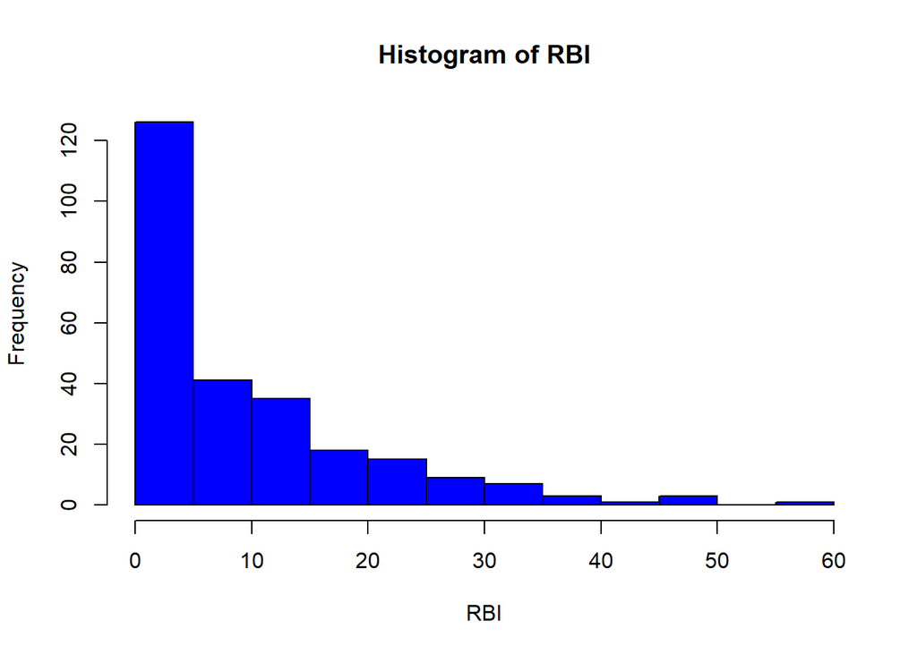

```r
hist(df$RBI,
     main = "Histogram of RBI",
     xlab = "RBI",
     ylab = "Frequency",
     col = "blue",
     border = "black")
```

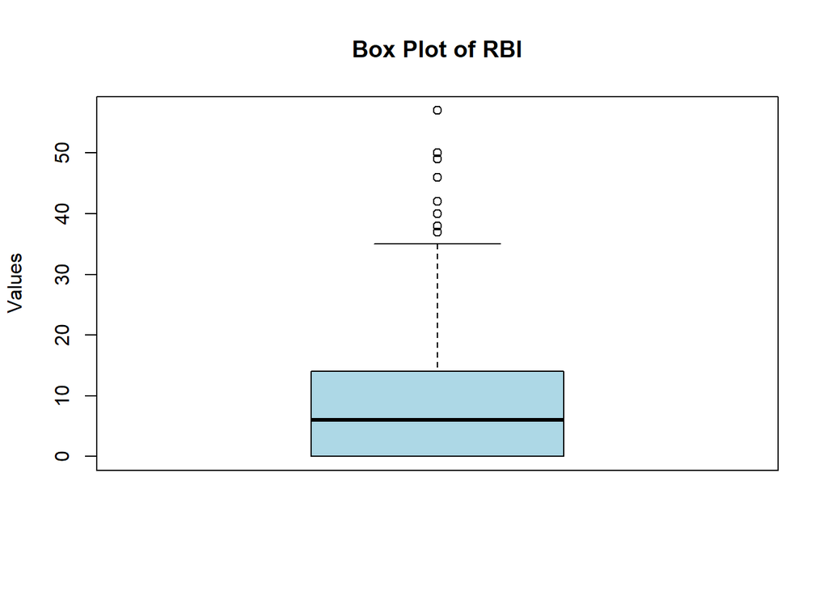

```r
boxplot(df$RBI,
        main = "Box Plot of RBI",
        ylab = "Values",
        col = "lightblue",
        border = "black",
        horizontal = FALSE)
```

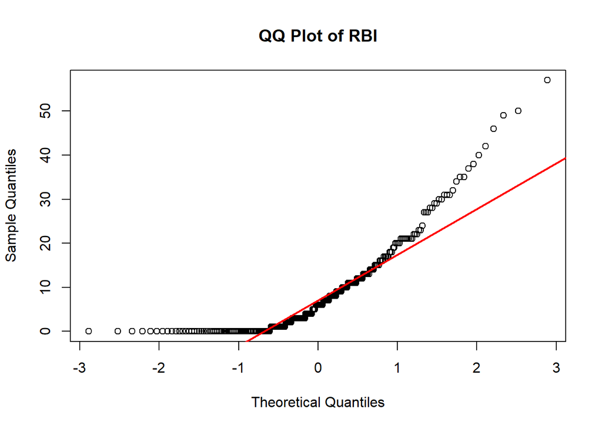

```r
qqnorm(df$RBI, main = "QQ Plot of RBI")
qqline(df$RBI, col = "red", lwd = 2)  # Adds a reference line
```

From the above graphical displays, I found that there were multiple outliers within the data and the distribution was heavily skewed. This is most likely due to the data including all players in the GAC, including starters, non-starters, and non-hitters.

Frequency and relative frequency tables for categorical variable, Teams. These values should closely align with roster count of each team in the GAC in the 2024 season.

```r
freq_table <- table(df$Team)
print(freq_table)
```

```
##
##   ATU   ECU   HSU    HU NWOSU   OKB   OUA   SAU   SNU  SOSU SWOSU   UAM
##    26    20    26    19    22    19    25    20    22    23    18    19
```

```r
rel_freq_table <- prop.table(freq_table)
print(rel_freq_table)
```

```
##
##        ATU        ECU        HSU         HU      NWOSU        OKB        OUA
## 0.10038610 0.07722008 0.10038610 0.07335907 0.08494208 0.07335907 0.09652510
##        SAU        SNU       SOSU      SWOSU        UAM
## 0.07722008 0.08494208 0.08880309 0.06949807 0.07335907
```

Two way table comparing games played and games started to determine number of starters on each team. A player is considered a starter if they start in 75% of games played. To be clear, this does not guarantee all starters are hitters, but it narrows down our data.

```r
df$Starters<-df$GS/df$GP>0.75
```

```r
table(df$Team,df$Starters)
```

```
##
##         FALSE TRUE
##   ATU      15   11
##   ECU      10   10
##   HSU      14   12
##   HU       10    9
##   NWOSU    11   11
##   OKB      12    7
##   OUA      13   12
##   SAU       9   11
##   SNU      13    9
##   SOSU      9   14
##   SWOSU     6   12
##   UAM       9   10
```

Null Hypothesis- True mean is equivalent to 15 RBIs

Alternative Hypothesis- True mean is not equivalent to 15 RBIs

```r
t.test(df$RBI,mu=15)
```

```
##
##  One Sample t-test
##
## data:  df$RBI
## t = -8.5233, df = 258, p-value = 1.319e-15
## alternative hypothesis: true mean is not equal to 15
## 95 percent confidence interval:
##   7.898954 10.564366
## sample estimates:
## mean of x
##   9.23166
```

We received a low p-value so we reject the null hypothesis. The true mean of RBIs among all players is not 15.

Null Hypothesis- True mean among starters is equivalent to 15 RBIs

Alternative Hypothesis- True mean among starters is not equivalent to 15 RBIs

```r
t.test(df[df$Starters,"RBI"],mu=15)
```

```
##
##  One Sample t-test
##
## data:  df[df$Starters, "RBI"]
## t = 0.90692, df = 127, p-value = 0.3662
## alternative hypothesis: true mean is not equal to 15
## 95 percent confidence interval:
##  13.90120 17.95818
## sample estimates:
## mean of x
##  15.92969
```

Null Hypothesis- True difference in means of RBIs of starters and non-starters is 0

Alternative Hypothesis- True difference in means of RBIs of starters and non-starters is not 0

```r
t.test(df[df$Starters,"RBI"],df[!df$Starters,"RBI"])
```

```
##
##  Welch Two Sample t-test
##
## data:  df[df$Starters, "RBI"] and df[!df$Starters, "RBI"]
## t = 12.2, df = 157.41, p-value < 2.2e-16
## alternative hypothesis: true difference in means is not equal to 0
## 95 percent confidence interval:
##  11.09868 15.38665
## sample estimates:
## mean of x mean of y
## 15.929688  2.687023
```

We received a low p-value so we reject the null hypothesis. The true difference in means of RBIs of starters and non-starters is not 0.

# Module 1

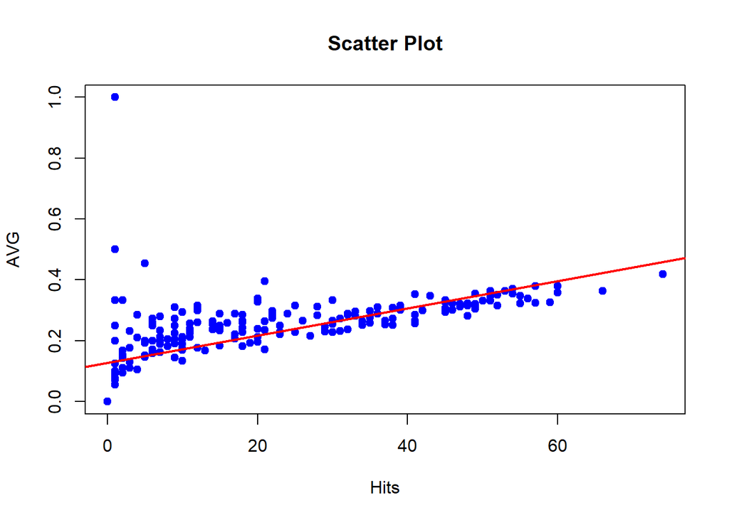

```r
plot(df$Hits, df$AVG,
     main = "Scatter Plot",
     xlab = "Hits",
     ylab = "AVG",
     col = "blue",
     pch = 19)

model <- lm(AVG ~ Hits, data = df)


abline(model, col = "red", lwd = 2)
```

```r
intercept <- coef(model)[1]
slope <- coef(model)[2]

eq <- paste0("y = ", round(intercept, 5), " + ", round(slope, 5), "x")
print(eq)
```

```
## [1] "y = 0.12828 + 0.00448x"
```

```r
cor(df$Hits, df$AVG)
```

```
## [1] 0.5702656
```

```r
cor.test(df$Hits, df$AVG)
```

```
##
##  Pearson's product-moment correlation
##
## data:  df$Hits and df$AVG
## t = 11.129, df = 257, p-value < 2.2e-16
## alternative hypothesis: true correlation is not equal to 0
## 95 percent confidence interval:
##  0.4818713 0.6471702
## sample estimates:
##       cor
## 0.5702656
```

While this does show a positive relationship between hits and batting average, it is not a very strong relationship. Lets look at and compare the correlations between and hits and batting average of starters and non starters.

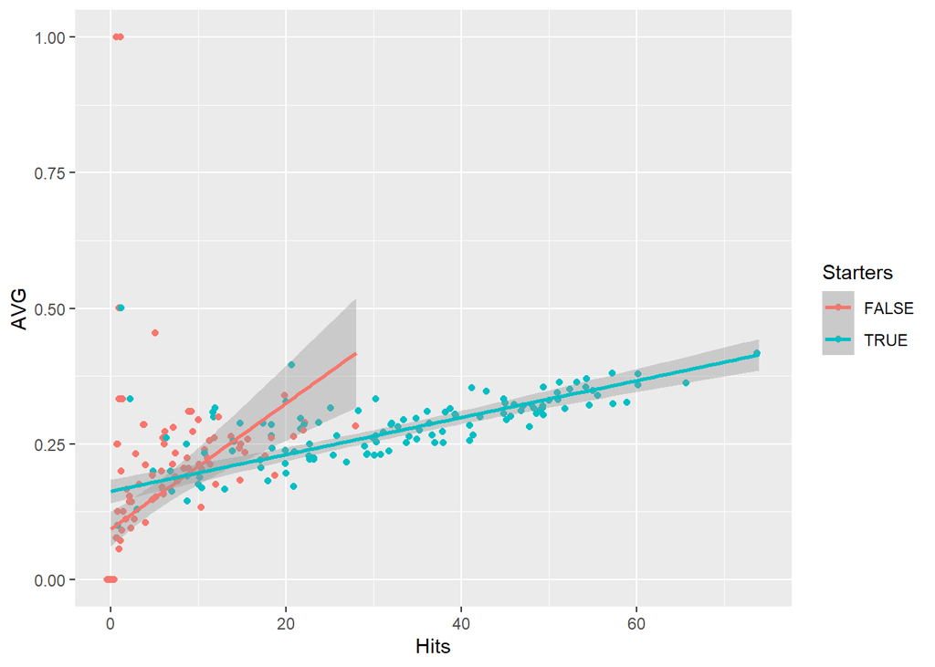

```r
ggplot(data = df, aes(x = Hits,y = AVG, colour = Starters))+
  geom_jitter()+
  geom_smooth(method = 'lm')
```

We can clearly see that among starters, the relationship between hits and batting average is strong. However, among non starters the relationship is very weak, as we would expect.

```r
predict(model,df[df$Player == "Watson",],interval="confidence")
```

```
##          fit       lwr       upr
## 43 0.2849102 0.2648356 0.3049848
```

```r
model$residuals[43]
```

```
##         43
## 0.01208978
```

Players actual average was 0.297 which is within our interval.

```r
predict(model,data.frame(Hits = c(50)))
```

```
##         1
## 0.3520355
```

Based on our regression, a player with 50 hits would have a 0.352 batting average.

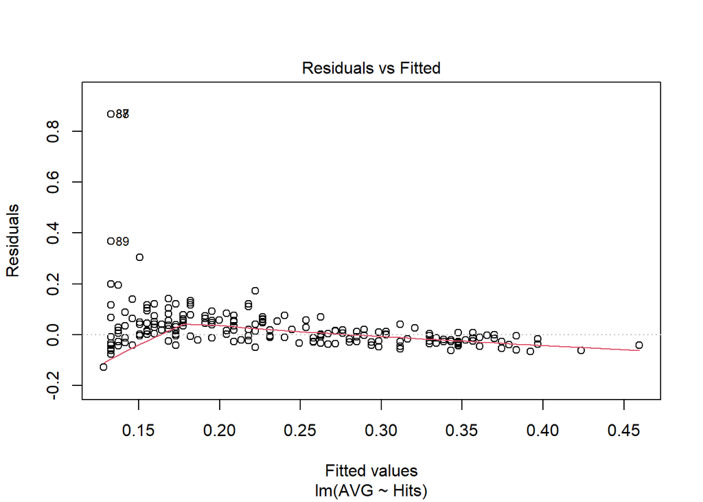

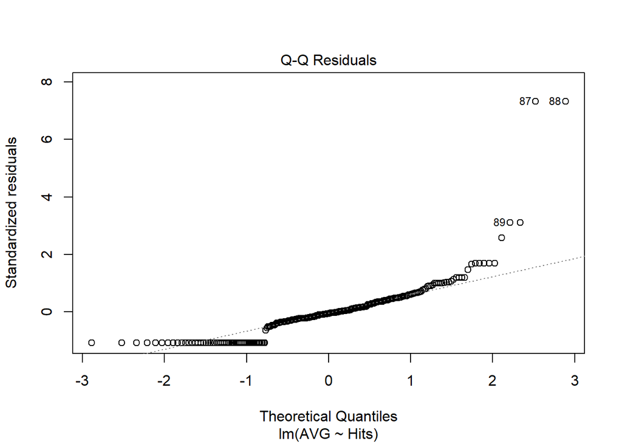

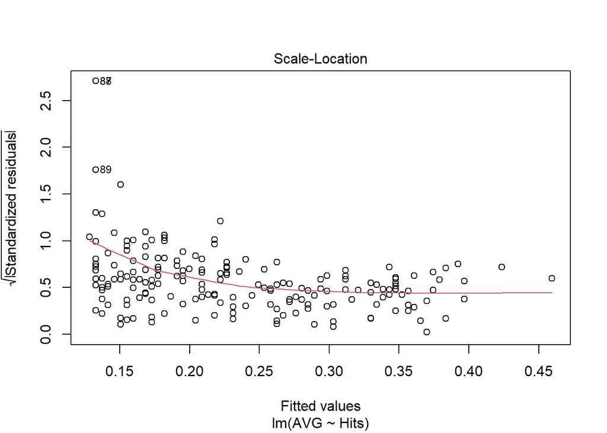

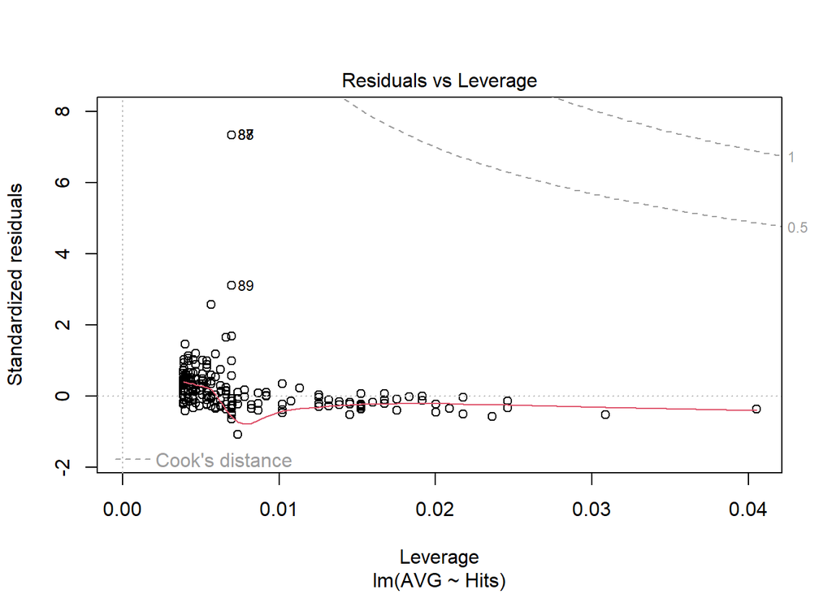

```r
plot(model)
```

```r
summary(model)
```

```
##
## Call:
## lm(formula = AVG ~ Hits, data = df)
##
## Residuals:
##      Min       1Q   Median       3Q      Max
## -0.12828 -0.05576 -0.00776  0.04547  0.86724
##
## Coefficients:
##              Estimate Std. Error t value Pr(>|t|)
## (Intercept) 0.1282845  0.0101909   12.59   <2e-16 ***
## Hits        0.0044750  0.0004021   11.13   <2e-16 ***
## ---
## Signif. codes:  0 '***' 0.001 '**' 0.01 '*' 0.05 '.' 0.1 ' ' 1
##
## Residual standard error: 0.1187 on 257 degrees of freedom
## Multiple R-squared:  0.3252, Adjusted R-squared:  0.3226
## F-statistic: 123.9 on 1 and 257 DF,  p-value: < 2.2e-16
```

```r
lm(AVG~.-Player-SB.ATT,df)
```

```
##
## Call:
## lm(formula = AVG ~ . - Player - SB.ATT, data = df)
##
## Coefficients:
##  (Intercept)       TeamECU       TeamHSU        TeamHU     TeamNWOSU
##   -0.0138007     0.0135736    -0.0065578     0.0041647     0.0156938
##      TeamOKB       TeamOUA       TeamSAU       TeamSNU      TeamSOSU
##   -0.0276728    -0.0102713     0.0002162    -0.0134915     0.0036186
##    TeamSWOSU       TeamUAM            GP            GS            AB
##   -0.0222082    -0.0134764     0.0002480     0.0007843    -0.0005441
##         Runs          Hits           X2B           X3B            HR
##    0.0003807     0.0025431     0.0003201    -0.0033075    -0.0046136
##          RBI            TB          SLGP            BB           HBP
##    0.0007224            NA     0.1263722    -0.0038040    -0.0042450
##           SO           GDP           OBP            SF            SH
##    0.0002330     0.0032653     0.6539758    -0.0003588     0.0005601
## StartersTRUE
##   -0.0102625
```

```r
aggregate(HBP ~ Team, data = df, FUN = sum)
```

```
##     Team HBP
## 1    ATU  24
## 2    ECU  31
## 3    HSU  36
## 4     HU  34
## 5  NWOSU  26
## 6    OKB  36
## 7    OUA  17
## 8    SAU  32
## 9    SNU  34
## 10  SOSU  38
## 11 SWOSU   9
## 12   UAM  21
```

Total HBP of each team in the GAC

# Module 2

We will now perform a bootstrap mean on RBIs and compare this to our mean we computed early on in Module 0. Original Hypothesis test: Null Hypothesis- True mean is equivalent to 15 RBIs Alternative Hypothesis- True mean is not equivalent to 15 RBIs

```r
library(boot)
boot_mean <- function(df, indices) {
  return(mean(df[indices]))
}
set.seed(123)
bootstrap_results <- boot(df$RBI, boot_mean, R = 1001)
print(bootstrap_results)
```

```
##
## ORDINARY NONPARAMETRIC BOOTSTRAP
##
##
## Call:
## boot(data = df$RBI, statistic = boot_mean, R = 1001)
##
##
## Bootstrap Statistics :
##     original     bias    std. error
## t1*  9.23166 0.02372917   0.6703846
```

Our original mean was 9.232 and the difference between our original mean and our bootstrap mean is 0.02373.This means our bootstrap mean is 9.255 RBIs.

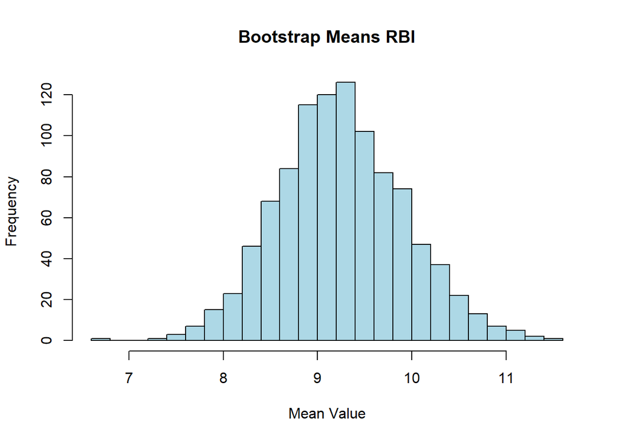

```r
hist(bootstrap_results$t, breaks = 30, main = "Bootstrap Means RBI", xlab = "Mean Value", col = "lightblue", border = "black")
```

```r
boot.ci(bootstrap_results, type = c("perc", "bca"))
```

```
## BOOTSTRAP CONFIDENCE INTERVAL CALCULATIONS
## Based on 1001 bootstrap replicates
##
## CALL :
## boot.ci(boot.out = bootstrap_results, type = c("perc", "bca"))
##
## Intervals :
## Level     Percentile            BCa
## 95%   ( 7.989, 10.663 )   ( 8.012, 10.719 )
## Calculations and Intervals on Original Scale
```

The 95% confidence interval for the mean is approximately between 7.989 and 10.663 RBIs.Since our null hypothesis of 15 RBI’s does not lie within our interval, we can reject the null hypothesis.

For my new hypothesis test: Null hypothesis- True median is equivalent to 7 BB’s (walks). Alternative hypothesis- True median is not equivalent to 7 BB’s (walks).

```r
library(boot)
boot_median <- function(df, indices) {
  return(median(df[indices]))
}
set.seed(123)
bootstrap_results <- boot(df$BB, boot_median, R = 1001)
print(bootstrap_results)
```

```
##
## ORDINARY NONPARAMETRIC BOOTSTRAP
##
##
## Call:
## boot(data = df$BB, statistic = boot_median, R = 1001)
##
##
## Bootstrap Statistics :
##     original     bias    std. error
## t1*        4 -0.0969031   0.4955809
```

My estimate was obviously pretty far off, I think if we could run the bootstrap mean on starters only it would have been more on target.

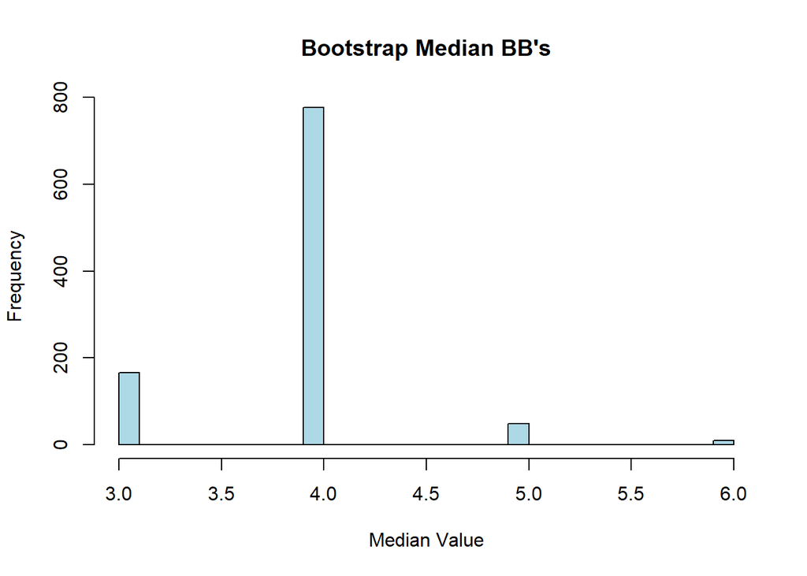

```r
hist(bootstrap_results$t, breaks = 30, main = "Bootstrap Median BB's", xlab = "Median Value", col = "lightblue", border = "black")
```

Unlike our bootstrap mean distribution, this distribution is not normal at all, which is to be expected.

```r
boot.ci(bootstrap_results, type = c("perc", "bca"))
```

```
## BOOTSTRAP CONFIDENCE INTERVAL CALCULATIONS
## Based on 1001 bootstrap replicates
##
## CALL :
## boot.ci(boot.out = bootstrap_results, type = c("perc", "bca"))
##
## Intervals :
## Level     Percentile            BCa
## 95%   ( 3,  5 )   ( 3,  4 )
## Calculations and Intervals on Original Scale
## Warning : BCa Intervals used Extreme Quantiles
## Some BCa intervals may be unstable
```

Onto Cross validation

```r
library(caret)
trainingsample <- createDataPartition(df$Hits, p=0.667,list=FALSE)
```

Randomly selected 2/3 of the data to be my training data.

```r
traindata <- df[trainingsample, ]
testdata <- df[-trainingsample, ]
```

Assigned this training data to traindata, and assigned the rest, the remaining 1/3, to be testdata.

```r
model <- lm(AVG ~ Hits, data = traindata)
summary(model)
```

```
##
## Call:
## lm(formula = AVG ~ Hits, data = traindata)
##
## Residuals:
##      Min       1Q   Median       3Q      Max
## -0.13476 -0.04889 -0.00939  0.04359  0.86085
##
## Coefficients:
##             Estimate Std. Error t value Pr(>|t|)
## (Intercept) 0.134764   0.013435  10.031  < 2e-16 ***
## Hits        0.004381   0.000540   8.113 8.79e-14 ***
## ---
## Signif. codes:  0 '***' 0.001 '**' 0.01 '*' 0.05 '.' 0.1 ' ' 1
##
## Residual standard error: 0.129 on 173 degrees of freedom
## Multiple R-squared:  0.2756, Adjusted R-squared:  0.2714
## F-statistic: 65.82 on 1 and 173 DF,  p-value: 8.788e-14
```

Created a linear model of our train data. Our r squared isn’t great, which makes sense because our original r squared wasn’t great.

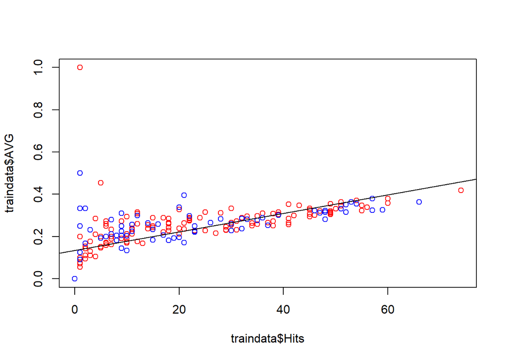

```r
plot(traindata$Hits,traindata$AVG,col="red")
points(testdata$Hits,testdata$AVG,col="blue")
abline(model)
```

Plotted our traindata (red) and testdata (blue) in a scatter plot along with our linear model.

```r
pre <- predict(model, testdata)
```

```r
R2(pre, testdata$AVG)
```

```
## [1] 0.4752341
```

Examined our predication on our test data.

```r
train.control <- trainControl(method="cv", number=10)
model <- train(AVG~Hits,
               data=df,
               method='lm',
               trControl=train.control)
print(model)
```

```
## Linear Regression
##
## 259 samples
##   1 predictor
##
## No pre-processing
## Resampling: Cross-Validated (10 fold)
## Summary of sample sizes: 233, 233, 233, 234, 233, 233, ...
## Resampling results:
##
##   RMSE       Rsquared   MAE
##   0.1100023  0.4313473  0.07466177
##
## Tuning parameter 'intercept' was held constant at a value of TRUE
```

Performed a 10-fold cross validation. Tbh idk what exactly this is telling me….